# Orvac Simulation Results

Mark Jones

2019-03-18 15:28:11

# 1 Preamble

Simulation results for ORVAC shown in graphical and table form.

## 1.1 Frequenist power/SS

Table 1 shows the statistical power from a log-rank test at sample sizes drawn from the simulation results (approx. expected SS from Bayesian trial having accrual of 40 per quarter).

Table 1. Frequentist power for time-to-event analysis

| Median Time to Evnt ctl | Median Time to Evnt trt | Median Time to Evnt diff | SS | Power |
| --- | --- | --- | --- | --- |
| 30 | 35 | 5 | 400 | 0.25 |
| 30 | 40 | 10 | 350 | 0.39 |
| 30 | 45 | 15 | 310 | 0.62 |
| 30 | 50 | 20 | 270 | 0.63 |

Table 2. Frequentist power for comparison of proportions

| Proportion Seroconverted ctl | Proportion Seroconverted trt | Proportion Seroconverted diff | SS | Power |
| --- | --- | --- | --- | --- |
| 0.2 | 0.3 | 0.1 | 150 | 0.41 |
| 0.3 | 0.4 | 0.1 | 150 | 0.36 |
| 0.4 | 0.5 | 0.1 | 150 | 0.34 |
| 0.2 | 0.4 | 0.2 | 150 | 0.85 |
| 0.3 | 0.5 | 0.2 | 150 | 0.81 |
| 0.4 | 0.6 | 0.2 | 150 | 0.79 |

# 2 Results from simulation scenarios

The following tables and plots summarise the scenarios that were simulated.

Analysis is all based on conjugate priors (vaguely informative for the time to event, uniform on seroconversion).

For the clinical endpoint we assess whether the probability of the ratio of median survival times is greater than 1 (equivalent to hazard ratio for the model used). Thresholds for deciding superiority was 0.96 at each interim and 0.95 at the final analysis. For the futility check, each trial that was simulated conditional on the current posterior was assessed against a threshold of 0.95. If less than 5% of the trials were successful (i.e. if in less than 5% of the trials we saw a treatment effect) then futility was declared.

For the immunological endpoint we assess whether the difference in seroconversion rates is greater than 0 (treatment versus control, i.e. one-sided). Stopping venous sampling was based on a threshold of 0.95, as was the final analysis. For the futility check, each trial simulated conditional on the current posterior was assessed against a threshold of 0.95 and if less than 5% of the trials were successful then futility was declared.

## 2.1 Reading the tables

From left to right tables show:

- true baseline median survival time
- delta_tte = (treatment median survival time) - (baseline median survival time)
- true baseline seroconversion probability
- delta_sero = (treatment seroconversion probability) - (baseline seroconversion probability)
- accrual – number of people per 3 month period (i.e. time between interims)
- information delay (in months) to obtain seroconversion results
- probability of expected success
- probability of expected futility
- probability of stopping venous sampling
- probability of no decision
- mean (sd) of participants enrolled
- mean (sd) of participants with blood sample results
- probability that trial stops before 250, 500 and 750 enrolled participants
- number of events in each arm (ctl/trt) at time trial stopped
- proportion of trials where the final analysis indicated a treatment difference in clinical endpoint
- proportion of trials where the final analysis indicated a treatment difference in immunological endpoint

## 2.2 Threshold Probabilities

Table 3 shows the threshold values used to assess adaptive elements in the simulations results that follow.

Table 3. Decision thresholds

| Threshold | Value | Description |
| --- | --- | --- |
| post_final_thresh | 0.95 | To assess each EPs at the final analysis. |
| pp_sero_sup_thresh | 0.95 | To assess whether venous sampling should be ceased due to superiority. |
| post_tte_sup_thresh | 0.96 | To assess whether clinical EP should be ceased due to expected success. |
| post_sero_win_thresh | 0.95 | To assess superiority in immunological EP for trials generated from posterior predictive distribution. |
| post_tte_win_thresh | 0.95 | To assess superiority in clinical EP for trials generated from posterior predictive distribution. |
| pp_sero_fut_thresh | 0.05 | To assess proportion of trials where immunological EP is successful during futility check. |
| pp_tte_fut_thresh | 0.05 | To assess proportion of trials where clinical EP is successful during futility check. |

## 2.3 Type I Error

Null scenarios showing control of type-i error < 0.05 on the clinical endpoint. However, note that the type-i for stopping venous sampling is > 0.05 for some scenarios. Therefore, I am going to increase the threshold used to assess whether we should stop venous sampling due to superiority from 0.95 to 0.96.

Table 4. Simulation Null Scenarios

| Clinical ctl | Clinical trt | Seroconversion ctl | Seroconversion trt | Info rate accrual | Info rate delay | Interim e.s. | Interim e.f | Interim s.v. | Interim n.d | SS enrolled | SS blood res | SS P(<250) | SS P(<500) | SS P(<750) | SS evnts | Wins @ final clin | Wins @ final immu | !Flip-flop clin | !Flip-flop immu | fname |
| --- | --- | --- | --- | --- | --- | --- | --- | --- | --- | --- | --- | --- | --- | --- | --- | --- | --- | --- | --- | --- |
| 30 | 30 | 0.8 | 0.8 | 60 | 1 | 0.023 | 0.973 | 0.037 | 0.004 | 200 (160.6) | 140 (66.7) | 0.71 | 0.93 | 0.98 | 12/12 | 0.051 | 0.052 | 0.93 | 0.92 | 2019-03-13-16-44-59 |
| 30 | 30 | 0.8 | 0.8 | 40 | 1 | 0.032 | 0.968 | 0.047 | 0.000 | 185 (155.2) | 131 (60.4) | 0.88 | 0.94 | 0.98 | 15/14 | 0.055 | 0.047 | 0.92 | 0.89 | 2019-03-13-16-29-33 |
| 30 | 30 | 0.3 | 0.3 | 60 | 1 | 0.020 | 0.978 | 0.036 | 0.002 | 192 (144.4) | 139 (67.2) | 0.72 | 0.96 | 0.98 | 10/10 | 0.056 | 0.047 | 0.93 | 0.91 | 2019-03-05-14-07-20 |
| 30 | 30 | 0.3 | 0.3 | 40 | 1 | 0.028 | 0.970 | 0.051 | 0.002 | 179 (142.2) | 130 (60.0) | 0.88 | 0.96 | 0.98 | 13/13 | 0.053 | 0.049 | 0.93 | 0.90 | 2019-03-05-13-48-22 |
| 30 | 30 | 0.3 | 0.3 | 20 | 1 | 0.042 | 0.956 | 0.221 | 0.002 | 177 (166.4) | 119 (52.3) | 0.85 | 0.94 | 0.97 | 22/22 | 0.055 | 0.047 | 0.92 | 0.82 | 2019-03-05-13-19-36 |
| 30 | 30 | 0.3 | 0.3 | 60 | 0 | 0.039 | 0.956 | 0.110 | 0.005 | 208 (194.1) | 137 (62.3) | 0.77 | 0.91 | 0.96 | 15/15 | 0.055 | 0.048 | 0.93 | 0.81 | 2019-03-05-12-03-55 |
| 30 | 30 | 0.3 | 0.3 | 40 | 0 | 0.033 | 0.964 | 0.117 | 0.003 | 172 (145.4) | 128 (56.1) | 0.89 | 0.96 | 0.98 | 13/13 | 0.056 | 0.049 | 0.93 | 0.89 | 2019-03-05-11-32-21 |
| 30 | 30 | 0.3 | 0.3 | 20 | 0 | 0.037 | 0.962 | 0.135 | 0.001 | 171 (161.2) | 119 (53.5) | 0.86 | 0.95 | 0.98 | 21/21 | 0.057 | 0.050 | 0.93 | 0.83 | 2019-03-05-11-03-50 |

Contrastingly, Table 5 contains the results when the futility rule is remove on both endpoints. The results suggest that without the futility rule, the type-i error would not be controlled at the 0.05 level. Also, the trials run for much, much longer.

Table 5. Simulation Null Scenarios without futility check

| Clinical ctl | Clinical trt | Seroconversion ctl | Seroconversion trt | Info rate accrual | Info rate delay | Interim e.s. | Interim e.f | Interim s.v. | Interim n.d | SS enrolled | SS blood res | SS P(<250) | SS P(<500) | SS P(<750) | SS evnts | Wins @ final clin | Wins @ final immu | !Flip-flop clin | !Flip-flop immu | fname |
| --- | --- | --- | --- | --- | --- | --- | --- | --- | --- | --- | --- | --- | --- | --- | --- | --- | --- | --- | --- | --- |
| 50 | 50 | 0.3 | 0.3 | 40 | 1 | 0.192 | 0.000 | 0.041 | 0.808 | 895 (236.8) | 212 (20.2) | 0.04 | 0.13 | 0.16 | 138/137 | 0.058 | 0.044 | 0.84 | 0.04 | 2019-03-18-00-27-09 |
| 20 | 20 | 0.3 | 0.3 | 40 | 1 | 0.202 | 0.000 | 0.042 | 0.798 | 886 (246.1) | 212 (20.8) | 0.05 | 0.13 | 0.18 | 265/263 | 0.068 | 0.045 | 0.84 | 0.04 | 2019-03-17-19-07-14 |
| 30 | 30 | 0.8 | 0.8 | 40 | 1 | 0.205 | 0.000 | 0.046 | 0.795 | 885 (247.0) | 212 (23.0) | 0.04 | 0.14 | 0.18 | 202/201 | 0.067 | 0.060 | 0.83 | 0.06 | 2019-03-17-13-55-51 |
| 30 | 30 | 0.4 | 0.4 | 40 | 1 | 0.203 | 0.000 | 0.034 | 0.797 | 888 (245.2) | 213 (17.0) | 0.04 | 0.14 | 0.17 | 203/202 | 0.071 | 0.041 | 0.85 | 0.04 | 2019-03-17-08-44-10 |
| 30 | 30 | 0.2 | 0.2 | 40 | 1 | 0.207 | 0.000 | 0.049 | 0.793 | 884 (248.4) | 212 (22.0) | 0.04 | 0.14 | 0.18 | 201/200 | 0.065 | 0.051 | 0.83 | 0.05 | 2019-03-17-03-29-54 |
| 30 | 30 | 0.3 | 0.3 | 40 | 1 | 0.193 | 0.000 | 0.048 | 0.807 | 898 (232.2) | 212 (21.9) | 0.04 | 0.11 | 0.16 | 205/205 | 0.051 | 0.048 | 0.84 | 0.05 | 2019-03-16-22-18-47 |
| 30 | 30 | 0.3 | 0.3 | 40 | 0 | 0.175 | 0.000 | 0.120 | 0.825 | 908 (221.4) | 217 (39.7) | 0.03 | 0.11 | 0.14 | 209/208 | 0.046 | 0.048 | 0.86 | 0.05 | 2019-03-16-17-01-30 |
| 30 | 30 | 0.3 | 0.3 | 20 | 1 | 0.188 | 0.000 | 0.085 | 0.812 | 892 (246.7) | 231 (35.6) | 0.06 | 0.14 | 0.16 | 208/208 | 0.054 | 0.053 | 0.86 | 0.05 | 2019-03-16-01-53-36 |

## 2.4 Expected Success

Baseline seroconversion rate equal to 0.3, baseline median event time equal to 30 months.

Note that the coloured points indicate the results from a new simulations that I initiated after identifying a minor, but not ignorable, bug in the code. The next run of simulation results will only show results from the new codebase.

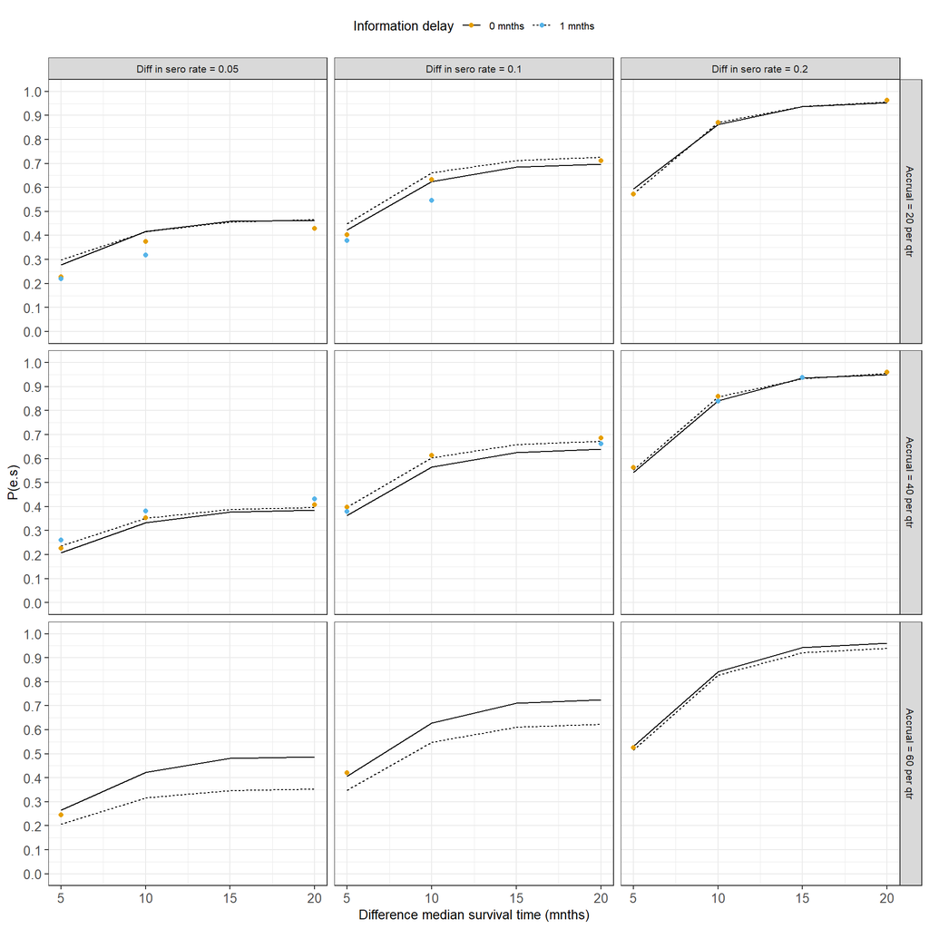

Additional plots for other subsets of the parameter space (information delay is 1 month, accrual 40 per quarter).

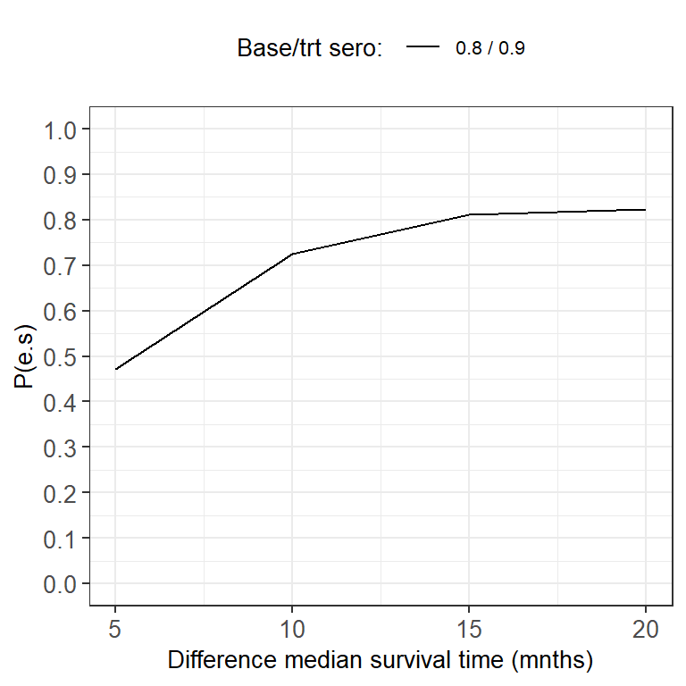

## 2.5 (Expected) Futility

Baseline seroconversion rate equal to 0.3, baseline median event time equal to 30 months.

Note that the coloured points indicate the results from a new simulations that I initiated after identifying a minor, but not ignorable, bug in the code. The next run of simulation results will only show results from the new codebase.

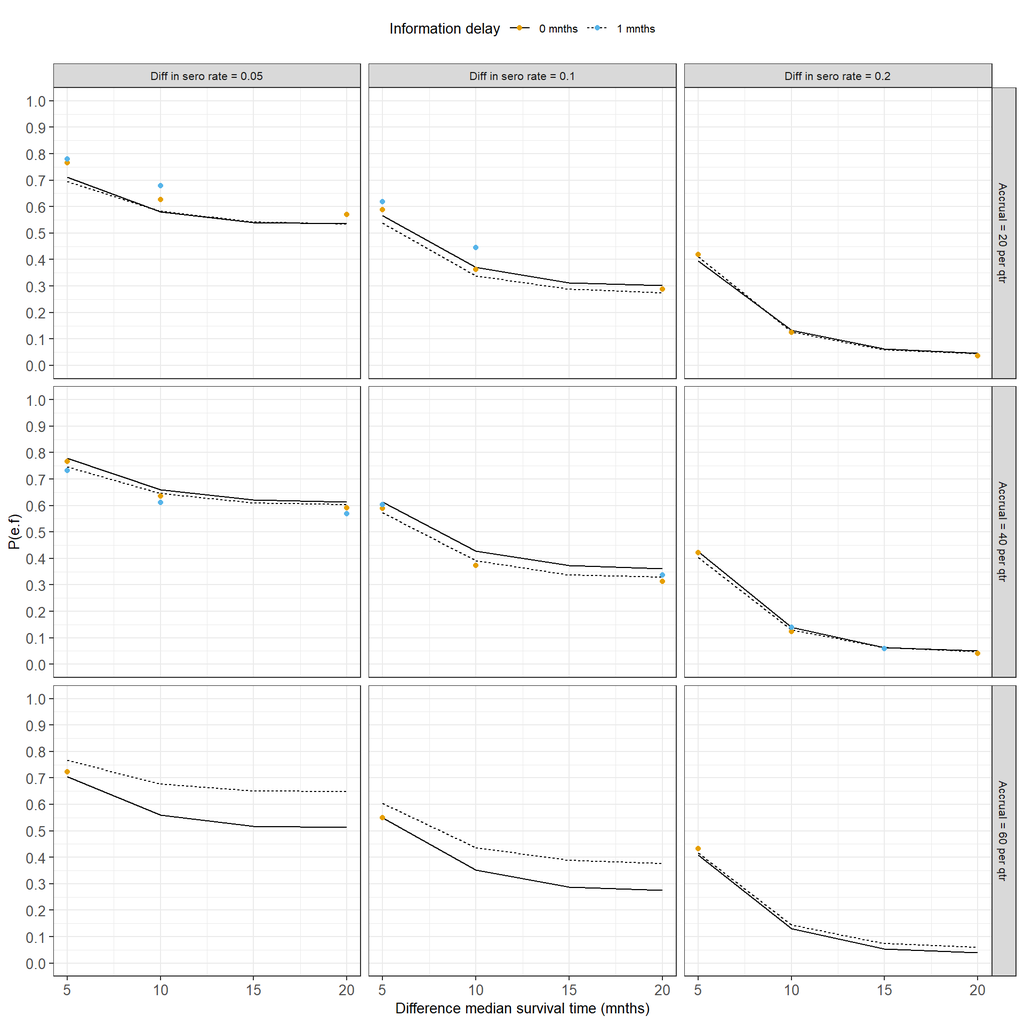

Additional plots for other subsets of the parameter space (information delay is 1 month, accrual 40 per quarter).

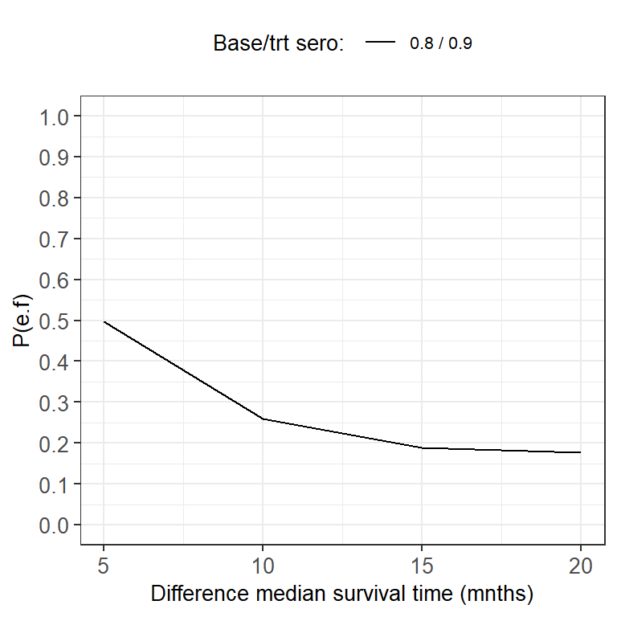

## 2.6 Stop Venous Sampling

Baseline seroconversion rate equal to 0.3, baseline median event time equal to 30 months.

Note that the coloured points indicate the results from a new simulations that I initiated after identifying a minor, but not ignorable, bug in the code. The next run of simulation results will only show results from the new codebase.

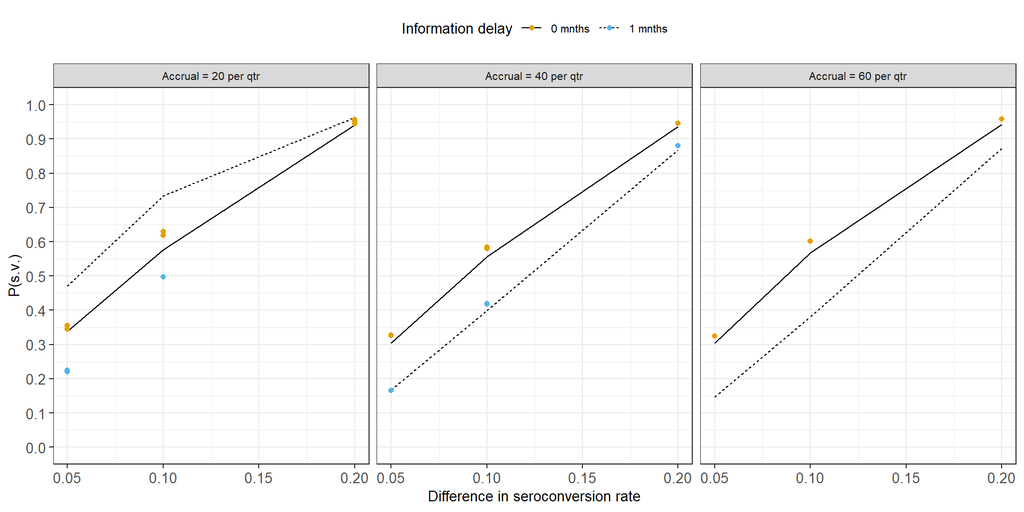

Additional plots for other subsets of the parameter space (information delay is 1 month, accrual 40 per quarter).

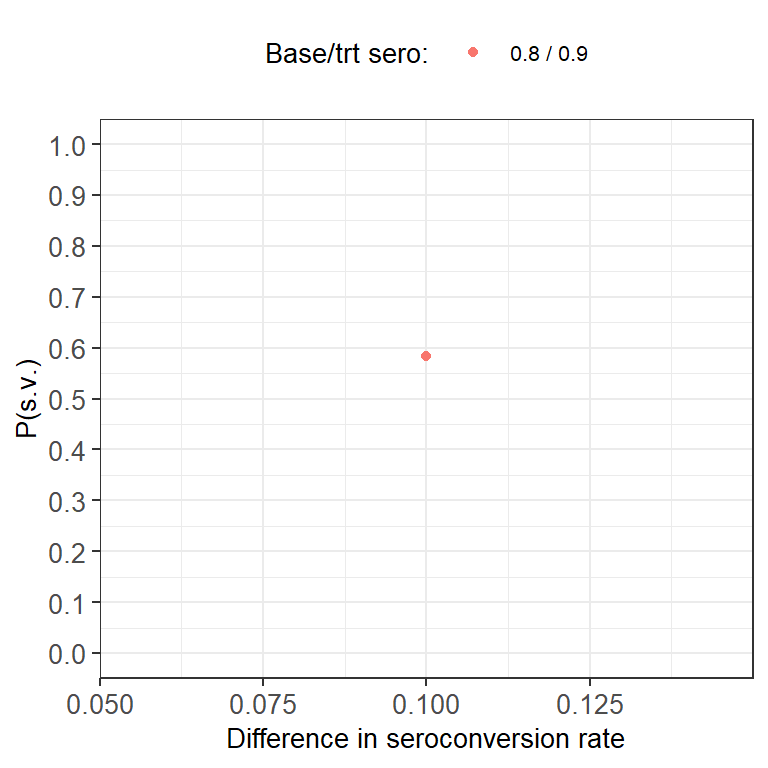

## 2.7 No Decision (Inconclusive)

Baseline seroconversion rate equal to 0.3, baseline median event time equal to 30 months.

Note that the coloured points indicate the results from a new simulations that I initiated after identifying a minor, but not ignorable, bug in the code. The next run of simulation results will only show results from the new codebase.

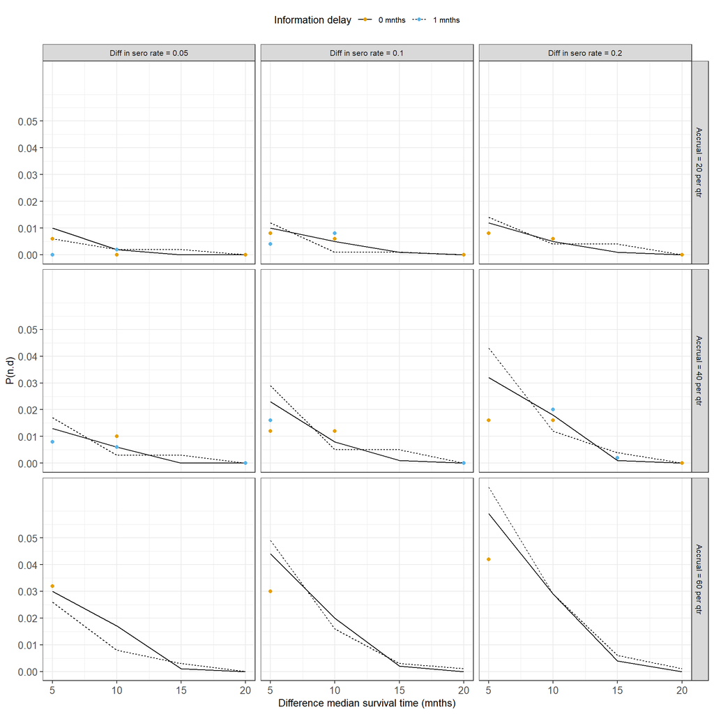

Additional plots for other subsets of the parameter space (information delay is 1 month, accrual 40 per quarter).

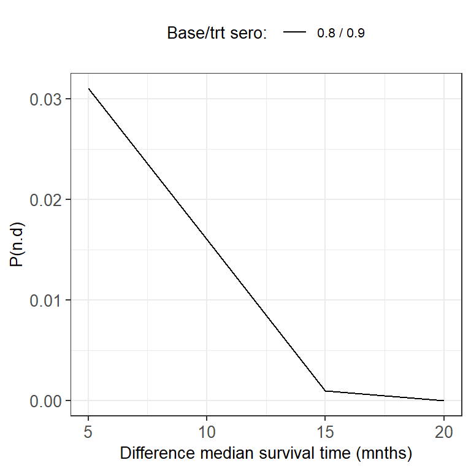

## 2.8 Sample Size

Baseline seroconversion rate equal to 0.3, baseline median event time equal to 30 months.

### 2.8.1 Total Enrolled

Note - information delay is 1 months (zero information delay showed as fainter line).

Note that the coloured points indicate the results from a new simulations that I initiated after identifying a minor, but not ignorable, bug in the code. The next run of simulation results will only show results from the new codebase.

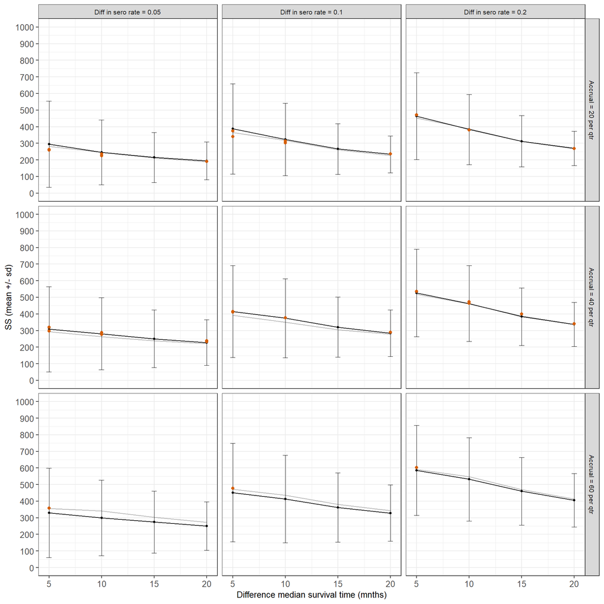

Additional plots for other subsets of the parameter space (information delay is 1 month, accrual 40 per quarter).

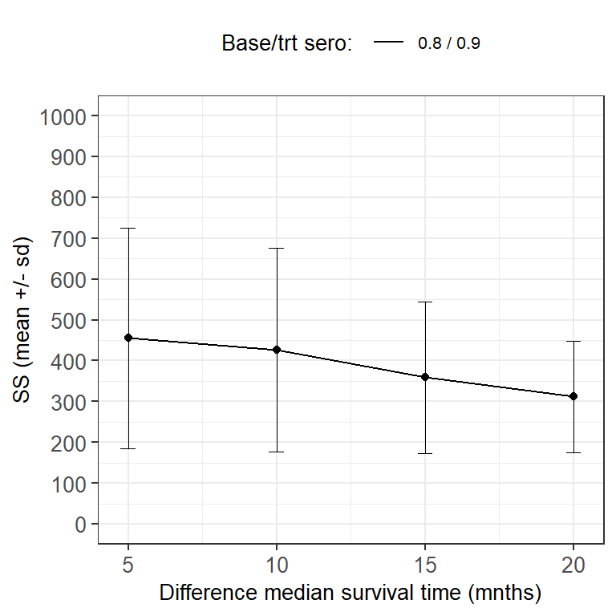

### 2.8.2 Cohort with Bloods Taken

Note that the coloured points indicate the results from a new simulations that I initiated after identifying a minor, but not ignorable, bug in the code. The next run of simulation results will only show results from the new codebase.

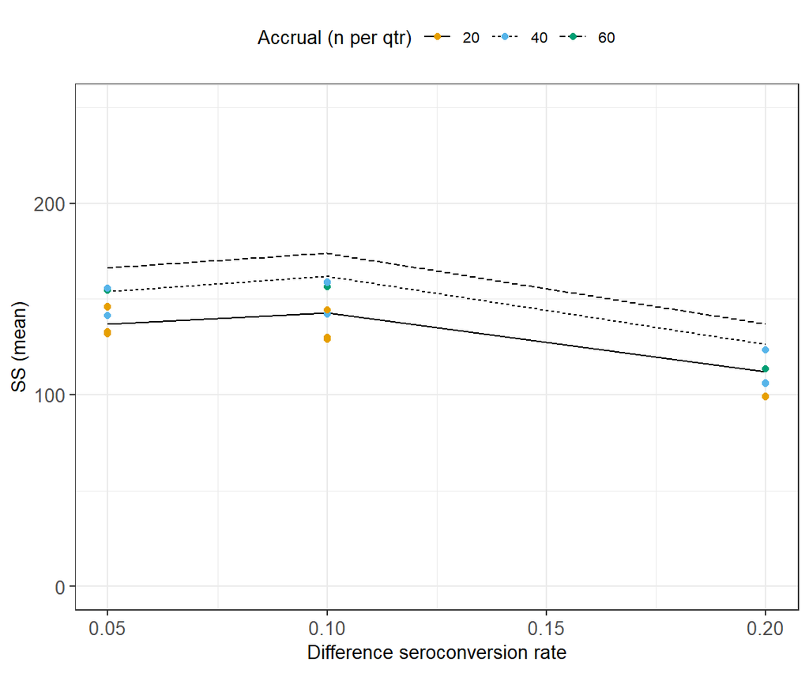

Additional plots for other subsets of the parameter space (information delay is 1 month, accrual 40 per quarter).

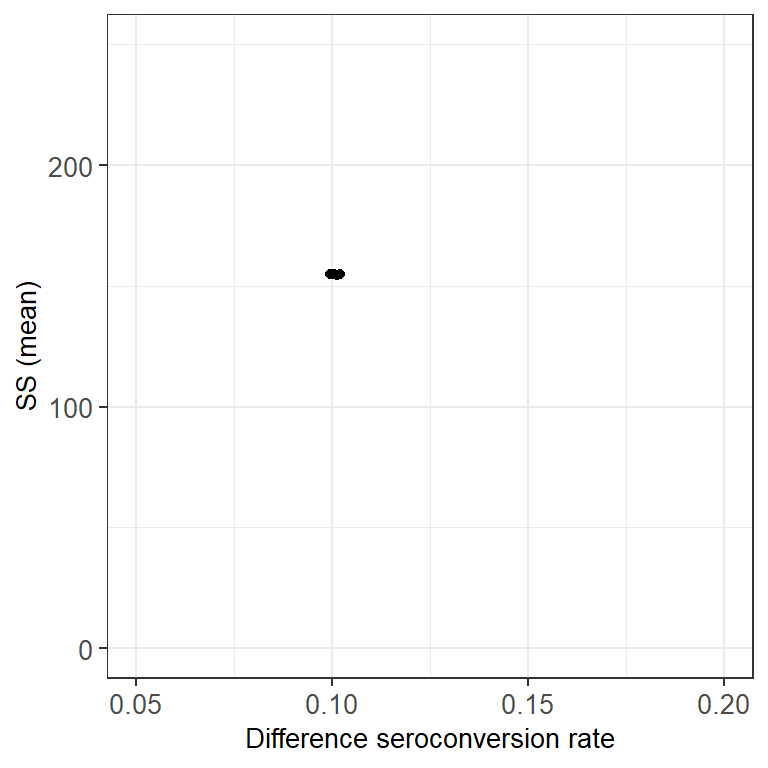

## 2.9 Consistency of Interim Decision with Final Analysis (flip-flop)

Shows the proportion of times that the final analysis is consistent with the interim decision that was made.

Baseline seroconversion rate equal to 0.3, baseline median event time equal to 30 months.

### 2.9.1 Clinical

Difference in sero of 0.05 still has quite high chance of futility.

The black dots show the results when the baseline seroconversion rate is 0.8, the treatment seroconversion rate is 0.9, the baseline time to event is 30 months and the treatment arm time to event ranges from 35 to 50.

Note that the coloured points indicate the results from a new simulations that I initiated after identifying a minor, but not ignorable, bug in the code. The next run of simulation results will only show results from the new codebase.

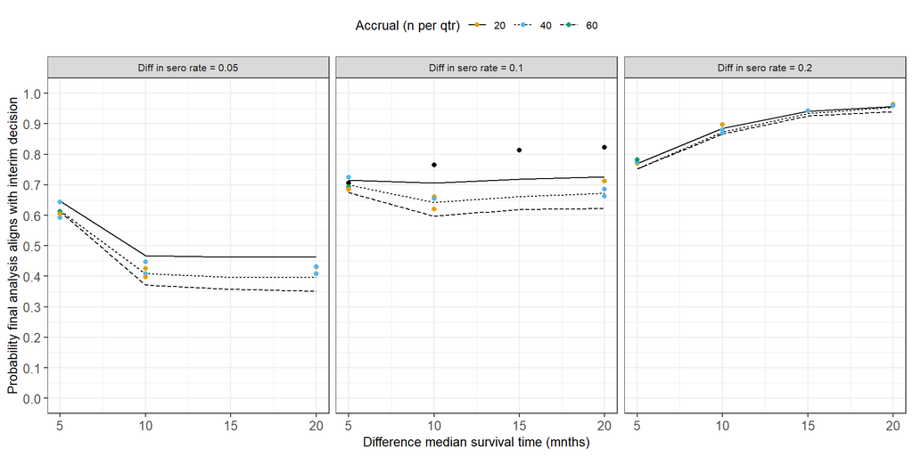

### 2.9.2 Immunological

Note that the coloured points indicate the results from a new simulations that I initiated after identifying a minor, but not ignorable, bug in the code. The next run of simulation results will only show results from the new codebase.

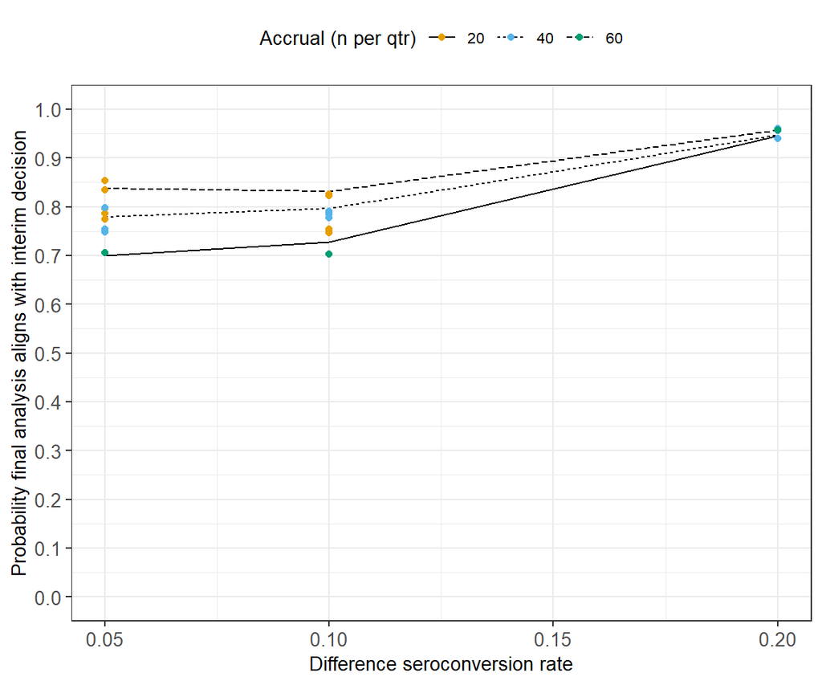

Additional plots for other subsets of the parameter space (information delay is 1 month, accrual 40 per quarter).

[figure not shown]

## 2.10 Combined Results

Table 6 shows the combined set of results generated in these simulations post 2019-03-13. These simulations were generated to see the effect of a minor bug fix in the code and constitute the latest most relevant results. The next run of simulation results will only show results from the new codebase.

| # | tte0 | delta_c | p0 | delta_i | accrual | info_delay | P(es) | P(ef) | P(sv) | P(nd) | SS_clin | SS_sero | P(SS<250) | P(SS<500) | P(SS<750) | Evnts | Win@Fin_clin | Win@Fin_sero | !FF_clin | !FF_sero |
| --- | --- | --- | --- | --- | --- | --- | --- | --- | --- | --- | --- | --- | --- | --- | --- | --- | --- | --- | --- | --- |
| 1 | 30 | 15 | 0.3 | 0.2 | 40 | 1 | 0.938 | 0.060 | 0.880 | 0.002 | 400 (182.0) | 123 (57.3) | 0.22 | 0.74 | 0.94 | 51/36 | 0.992 | 0.954 | 0.94 | 0.94 |
| 2 | 30 | 10 | 0.3 | 0.2 | 40 | 1 | 0.840 | 0.140 | 0.880 | 0.020 | 474 (231.1) | 123 (57.2) | 0.18 | 0.60 | 0.84 | 70/55 | 0.902 | 0.954 | 0.87 | 0.94 |
| 3 | 30 | 20 | 0.3 | 0.1 | 40 | 1 | 0.662 | 0.338 | 0.420 | 0.000 | 289 (147.2) | 159 (60.1) | 0.52 | 0.91 | 0.98 | 29/19 | 1.000 | 0.486 | 0.66 | 0.78 |
| 4 | 30 | 5 | 0.3 | 0.1 | 40 | 1 | 0.380 | 0.604 | 0.418 | 0.016 | 411 (272.7) | 159 (60.0) | 0.41 | 0.67 | 0.82 | 59/51 | 0.516 | 0.500 | 0.72 | 0.79 |
| 5 | 30 | 20 | 0.3 | 0.05 | 40 | 1 | 0.432 | 0.568 | 0.166 | 0.000 | 238 (144.0) | 156 (60.0) | 0.70 | 0.94 | 0.99 | 21/14 | 1.000 | 0.210 | 0.43 | 0.75 |
| 6 | 30 | 10 | 0.3 | 0.05 | 40 | 1 | 0.382 | 0.612 | 0.166 | 0.006 | 287 (212.6) | 156 (60.0) | 0.64 | 0.82 | 0.95 | 32/25 | 0.910 | 0.206 | 0.45 | 0.75 |
| 7 | 30 | 5 | 0.3 | 0.05 | 40 | 1 | 0.260 | 0.732 | 0.166 | 0.008 | 321 (262.8) | 156 (60.0) | 0.62 | 0.78 | 0.87 | 41/35 | 0.508 | 0.212 | 0.64 | 0.75 |
| 8 | 30 | 10 | 0.3 | 0.1 | 20 | 1 | 0.546 | 0.446 | 0.498 | 0.008 | 302 (199.1) | 144 (61.4) | 0.54 | 0.84 | 0.95 | 49/39 | 0.902 | 0.500 | 0.62 | 0.82 |
| 9 | 30 | 5 | 0.3 | 0.1 | 20 | 1 | 0.378 | 0.618 | 0.498 | 0.004 | 341 (245.1) | 144 (61.4) | 0.53 | 0.77 | 0.89 | 59/51 | 0.508 | 0.500 | 0.69 | 0.83 |
| 10 | 30 | 10 | 0.3 | 0.05 | 20 | 1 | 0.318 | 0.680 | 0.224 | 0.002 | 225 (166.3) | 146 (62.6) | 0.72 | 0.92 | 0.98 | 32/25 | 0.900 | 0.220 | 0.40 | 0.83 |

[output cut: 34 more lines]

Table 7 shows the combined set of results generated in these simulations pre 2019-03-13.

| Clinical ctl | Clinical trt | Seroconversion ctl | Seroconversion trt | Info rate accrual | Info rate delay | Interim e.s. | Interim e.f | Interim s.v. | Interim n.d | SS enrolled | SS blood res | SS P(<250) | SS P(<500) | SS P(<750) | SS evnts | Wins @ final clin | Wins @ final immu | !Flip-flop clin | !Flip-flop immu | fname |
| --- | --- | --- | --- | --- | --- | --- | --- | --- | --- | --- | --- | --- | --- | --- | --- | --- | --- | --- | --- | --- |
| 30 | 50 | 0.8 | 0.90 | 40 | 1 | 0.823 | 0.177 | 0.583 | 0.000 | 312 (136.9) | 155 (59.3) | 0.42 | 0.90 | 0.98 | 32/20 | 1.000 | 0.732 | 0.82 | 0.84 | 2019-03-13-23-11-48 |
| 30 | 45 | 0.8 | 0.90 | 40 | 1 | 0.811 | 0.188 | 0.583 | 0.001 | 359 (185.6) | 155 (59.2) | 0.37 | 0.79 | 0.95 | 43/30 | 0.994 | 0.739 | 0.81 | 0.84 | 2019-03-13-22-09-33 |
| 30 | 40 | 0.8 | 0.90 | 40 | 1 | 0.725 | 0.259 | 0.583 | 0.016 | 427 (249.0) | 155 (59.2) | 0.32 | 0.68 | 0.85 | 60/47 | 0.916 | 0.733 | 0.76 | 0.84 | 2019-03-13-20-46-03 |
| 30 | 35 | 0.8 | 0.90 | 40 | 1 | 0.472 | 0.497 | 0.584 | 0.031 | 455 (270.8) | 155 (59.2) | 0.32 | 0.63 | 0.80 | 68/59 | 0.522 | 0.733 | 0.71 | 0.84 | 2019-03-13-18-51-15 |
| 30 | 30 | 0.8 | 0.80 | 60 | 1 | 0.023 | 0.973 | 0.037 | 0.004 | 200 (160.6) | 140 (66.7) | 0.71 | 0.93 | 0.98 | 12/12 | 0.051 | 0.052 | 0.93 | 0.92 | 2019-03-13-16-44-59 |
| 30 | 30 | 0.8 | 0.80 | 40 | 1 | 0.032 | 0.968 | 0.047 | 0.000 | 185 (155.2) | 131 (60.4) | 0.88 | 0.94 | 0.98 | 15/14 | 0.055 | 0.047 | 0.92 | 0.89 | 2019-03-13-16-29-33 |
| 30 | 50 | 0.3 | 0.50 | 60 | 1 | 0.939 | 0.060 | 0.872 | 0.001 | 406 (161.2) | 137 (63.9) | 0.03 | 0.77 | 0.97 | 36/23 | 1.000 | 0.950 | 0.94 | 0.96 | 2019-03-12-03-33-02 |
| 30 | 45 | 0.3 | 0.50 | 60 | 1 | 0.921 | 0.073 | 0.872 | 0.006 | 460 (203.5) | 137 (63.9) | 0.03 | 0.66 | 0.90 | 49/34 | 0.991 | 0.949 | 0.93 | 0.96 | 2019-03-12-01-57-44 |
| 30 | 40 | 0.3 | 0.50 | 60 | 1 | 0.827 | 0.144 | 0.872 | 0.029 | 532 (250.3) | 137 (63.9) | 0.03 | 0.54 | 0.79 | 69/53 | 0.920 | 0.950 | 0.87 | 0.96 | 2019-03-12-00-00-31 |
| 30 | 35 | 0.3 | 0.50 | 60 | 1 | 0.515 | 0.416 | 0.872 | 0.069 | 586 (271.5) | 137 (64.0) | 0.03 | 0.48 | 0.69 | 84/72 | 0.502 | 0.947 | 0.75 | 0.96 | 2019-03-11-21-35-29 |
| 30 | 50 | 0.3 | 0.40 | 60 | 1 | 0.622 | 0.377 | 0.379 | 0.001 | 328 (169.3) | 174 (65.6) | 0.22 | 0.86 | 0.98 | 26/16 | 1.000 | 0.503 | 0.62 | 0.83 | 2019-03-11-18-48-51 |
| 30 | 45 | 0.3 | 0.40 | 60 | 1 | 0.609 | 0.388 | 0.380 | 0.003 | 362 (208.2) | 174 (65.7) | 0.22 | 0.79 | 0.94 | 33/23 | 0.990 | 0.507 | 0.62 | 0.83 | 2019-03-11-17-44-35 |
| 30 | 40 | 0.3 | 0.40 | 60 | 1 | 0.547 | 0.437 | 0.380 | 0.016 | 413 (263.2) | 174 (65.9) | 0.22 | 0.70 | 0.86 | 47/36 | 0.926 | 0.502 | 0.60 | 0.83 | 2019-03-11-16-26-48 |
| 30 | 35 | 0.3 | 0.40 | 60 | 1 | 0.347 | 0.604 | 0.381 | 0.049 | 451 (296.4) | 174 (65.8) | 0.22 | 0.65 | 0.79 | 59/50 | 0.515 | 0.508 | 0.67 | 0.83 | 2019-03-11-14-48-39 |
| 30 | 50 | 0.3 | 0.35 | 60 | 1 | 0.351 | 0.649 | 0.147 | 0.000 | 250 (146.1) | 166 (66.4) | 0.46 | 0.94 | 0.99 | 15/10 | 1.000 | 0.214 | 0.35 | 0.83 | 2019-03-11-12-55-47 |
| 30 | 45 | 0.3 | 0.35 | 60 | 1 | 0.346 | 0.651 | 0.147 | 0.003 | 274 (186.4) | 166 (66.4) | 0.46 | 0.90 | 0.97 | 21/14 | 0.989 | 0.214 | 0.36 | 0.83 | 2019-03-11-12-20-27 |
| 30 | 40 | 0.3 | 0.35 | 60 | 1 | 0.315 | 0.677 | 0.146 | 0.008 | 300 (226.9) | 166 (66.4) | 0.46 | 0.84 | 0.94 | 27/21 | 0.922 | 0.208 | 0.37 | 0.82 | 2019-03-11-11-35-24 |
| 30 | 35 | 0.3 | 0.35 | 60 | 1 | 0.206 | 0.768 | 0.147 | 0.026 | 330 (269.7) | 166 (66.4) | 0.46 | 0.80 | 0.88 | 36/30 | 0.512 | 0.222 | 0.61 | 0.84 | 2019-03-11-10-39-56 |
| 30 | 50 | 0.3 | 0.50 | 40 | 1 | 0.954 | 0.046 | 0.867 | 0.000 | 337 (132.3) | 126 (57.6) | 0.30 | 0.88 | 0.99 | 36/23 | 1.000 | 0.949 | 0.95 | 0.95 | 2019-03-11-09-32-56 |
| 30 | 45 | 0.3 | 0.50 | 40 | 1 | 0.932 | 0.064 | 0.867 | 0.004 | 384 (173.4) | 126 (57.6) | 0.24 | 0.77 | 0.95 | 47/33 | 0.993 | 0.951 | 0.93 | 0.95 | 2019-03-11-07-48-51 |
| 30 | 40 | 0.3 | 0.50 | 40 | 1 | 0.858 | 0.130 | 0.868 | 0.012 | 462 (228.7) | 126 (57.6) | 0.18 | 0.63 | 0.85 | 67/52 | 0.917 | 0.951 | 0.87 | 0.95 | 2019-03-11-05-33-25 |
| 30 | 35 | 0.3 | 0.50 | 40 | 1 | 0.553 | 0.404 | 0.868 | 0.043 | 526 (263.1) | 126 (57.7) | 0.15 | 0.52 | 0.75 | 83/72 | 0.510 | 0.949 | 0.75 | 0.95 | 2019-03-11-02-28-14 |
| 30 | 50 | 0.3 | 0.40 | 40 | 1 | 0.671 | 0.329 | 0.397 | 0.000 | 285 (140.1) | 162 (59.2) | 0.51 | 0.92 | 0.99 | 28/18 | 1.000 | 0.503 | 0.67 | 0.79 | 2019-03-10-22-41-47 |
| 30 | 45 | 0.3 | 0.40 | 40 | 1 | 0.657 | 0.338 | 0.400 | 0.005 | 320 (180.9) | 162 (59.3) | 0.46 | 0.84 | 0.97 | 36/26 | 0.992 | 0.503 | 0.66 | 0.79 | 2019-03-10-21-24-51 |
| 30 | 40 | 0.3 | 0.40 | 40 | 1 | 0.603 | 0.392 | 0.399 | 0.005 | 374 (238.1) | 162 (59.3) | 0.42 | 0.74 | 0.89 | 49/38 | 0.921 | 0.505 | 0.64 | 0.79 | 2019-03-10-19-44-44 |
| 30 | 35 | 0.3 | 0.40 | 40 | 1 | 0.397 | 0.574 | 0.399 | 0.029 | 415 (276.8) | 162 (59.3) | 0.41 | 0.68 | 0.82 | 60/52 | 0.511 | 0.509 | 0.70 | 0.80 | 2019-03-10-17-31-36 |
| 30 | 50 | 0.3 | 0.35 | 40 | 1 | 0.396 | 0.604 | 0.168 | 0.000 | 228 (136.9) | 154 (60.6) | 0.72 | 0.95 | 0.99 | 19/12 | 1.000 | 0.210 | 0.40 | 0.78 | 2019-03-10-14-51-37 |
| 30 | 45 | 0.3 | 0.35 | 40 | 1 | 0.388 | 0.609 | 0.168 | 0.003 | 250 (173.6) | 154 (60.6) | 0.68 | 0.90 | 0.98 | 24/17 | 0.992 | 0.217 | 0.40 | 0.79 | 2019-03-10-14-02-47 |
| 30 | 40 | 0.3 | 0.35 | 40 | 1 | 0.352 | 0.645 | 0.167 | 0.003 | 281 (217.0) | 154 (60.6) | 0.65 | 0.84 | 0.94 | 32/25 | 0.919 | 0.207 | 0.41 | 0.78 | 2019-03-10-13-01-33 |
| 30 | 35 | 0.3 | 0.35 | 40 | 1 | 0.237 | 0.746 | 0.167 | 0.017 | 308 (256.3) | 154 (60.6) | 0.64 | 0.80 | 0.89 | 39/34 | 0.511 | 0.209 | 0.62 | 0.78 | 2019-03-10-11-39-17 |

[output cut: 54 more lines]